# Insurance-Prediction

For this guided project, I'll be looking at the [Medical Cost Data Set from Kaggle](https://www.kaggle.com/datasets/mirichoi0218/insurance?resource=download). This dataset contains information on individual medical insurance bills. Each bill is associated with some demographic and personal characteristics of the person who received it.

For the regression problem, i'm interested in how these different characteristics relate to the total medical cost. It's a continuous, positive number, which makes it a good candidate for a linear regression. For this guided project, I want to construct the best possible predictive model for the cost, given some information about the patient. Predicting medical costs is an important task because it allows hospitals to predict revenue and plan necessary procedures needed by its patient population.

Let's get started!

```python
import pandas as pd
import numpy as np
from sklearn.linear_model import LinearRegression
from sklearn.metrics import mean_squared_error, r2_score
from sklearn.model_selection import train_test_split

pd.options.display.max_columns=100
```

```python
insurance = pd.read_csv('insurance.csv')
insurance.head()
# the target column(the variable I'm trying to predict) is the charges column
# the success of my algorithm can be told by how accurate it is at predicting
# it.
print(insurance.shape)
```

```
(1338, 7)
```

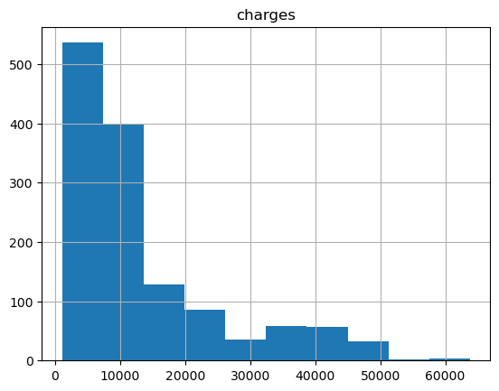

```
(1059.224, 7386.729]      536
(7386.729, 13651.585]     398
(13651.585, 19916.44]     129
(19916.44, 26181.296]      86
(32446.151, 38711.006]     59
(38711.006, 44975.862]     57
(26181.296, 32446.151]     35
(44975.862, 51240.717]     32
(57505.573, 63770.428]      4
(51240.717, 57505.573]      2
Name: charges, dtype: int64
```

```python
import matplotlib.pyplot as plt
insurance.hist('charges')
plt.show()
insurance['charges'].value_counts(bins=10)
```

The `charges` column is highly skewed to the right. Extremely costly insurance charges are less common than extremely small ones. This makes it unlikely that the errors in the model will truly be centered at zero. It might be worth it to log-transform the outcome.

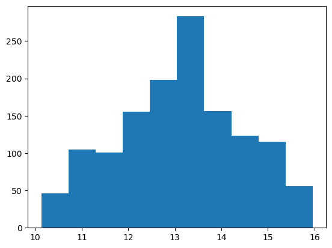

```python
insurance['log_charges']=np.log2(insurance['charges'])
plt.hist(insurance['log_charges'])
```

# Exploring The Dataset

The first step in developing my linear model is exploring the insurance dataset. Variables that are highly correlated with the outcome are better candidates for use in a predictive linear regression model. However, if there are multiple predictors that are highly correlated with each other, it might be better to try them all and see which combination produces the better model.

### Dataset columns

- age: age of primary beneficiary
- sex: insurance contractor gender, female, male
- bmi: Body mass index, providing an understanding of body, weights that are relatively high or low relative to height, objective index of body weight (kg / m ^ 2) using the ratio of height to weight, ideally 18.5 to 24.9
- children: Number of children covered by health insurance / Number of dependents
- smoker: Smoking
- region: the beneficiary's residential area in the US, northeast, southeast, southwest, northwest.
- charges: Individual medical costs billed by health insurance

# Finding correlations

In order to find the correlation between the string columns and the target variable, I've decided to convert them all into dummy variables (eg. gender column will now be gender_male, and gender_female columns, gender_male column will have 1 for male and 0 for not male)

[figure not shown]

|  | age | bmi | children | charges | log_charges | sex_male | smoker_yes | region_northwest | region_southeast | region_southwest |
| --- | --- | --- | --- | --- | --- | --- | --- | --- | --- | --- |
| 0 | 19 | 27.900 | 0 | 16884.92400 | 14.043448 | 0 | 1 | 0 | 0 | 1 |
| 1 | 18 | 33.770 | 1 | 1725.55230 | 10.752842 | 1 | 0 | 0 | 1 | 0 |
| 2 | 28 | 33.000 | 3 | 4449.46200 | 12.119415 | 1 | 0 | 0 | 1 | 0 |
| 3 | 33 | 22.705 | 0 | 21984.47061 | 14.424197 | 1 | 0 | 1 | 0 | 0 |
| 4 | 32 | 28.880 | 0 | 3866.85520 | 11.916945 | 1 | 0 | 1 | 0 | 0 |

```python
plt.show()
data1=pd.get_dummies(insurance,drop_first=True)
data1.head()
```

```python
data1.corr()['charges']
```

```
age                 0.299008
bmi                 0.198341
children            0.067998
charges             1.000000
log_charges         0.892964
sex_male            0.057292
smoker_yes          0.787251
region_northwest   -0.039905
region_southeast    0.073982
region_southwest   -0.043210
Name: charges, dtype: float64
```

### Comments on correlation

The strongest Predictors of high insurance charges are being a smoker(78%), rising age(30%) and rising bmi(20%)

# Dividing The Data

Before I can start building the model, I must divide the insurance dataset into two portions:

- A training set that will be used to estimate the regression coefficients
- A test set that will be used to assess the predictive ability of the model

I need a training set in order to estimate the regression coefficients for each of the predictors in the model. So, it's crucial that the test dataset is not used to estimate the coefficients because it's supposed to represent new data on which to make predictions. The model is not fit to this data, so the prediction error here helps me understand how the model can be generalized.

```python
X=data1[['age','bmi','smoker_yes']]
y=data1['log_charges']
```

```python
X_train,X_test,y_train,y_test = train_test_split(X,y,test_size=.2,random_state=729)
# random state is set for reproducibility
```

# Build The Model

Now that I've divided up the data into both a training and test set, I'm ready to build my very own predictive linear model. After I build the model, take the time to examine the regression coefficients and the coefficient of determination. I can ask myself a few things:

- Do the coefficient values make sense considering their correlation with the outcome?
- What does the coefficient of determination suggest about the model fit?
- How well does the model predict the medical costs in the training set?

Build the model, and write a little bit about what you find.

```python
model = LinearRegression()
model.fit(X_train,y_train)
coefficients=model.coef_
print(coefficients)
# Get predicted values by model
charge_predictions= model.predict(X_train)
mean_squared_error(y_train,charge_predictions)
```

```
[0.05026514 0.01732919 2.25222063]
```

```
0.46408588618235874
```

```python
# Coefficient of determination 'R²'
r2_score(y_train, charge_predictions)
```

```
0.7408451472468827
```

```python
# I used the logarithm to get a more distributed set of charges, now to get
# a more accurate MSE of the charge column, i'll have to use euler's number(e)
# that is what np.exp does:
np.exp(mean_squared_error(y_train, charge_predictions))
```

```
1.5905595716633008
```

### Comments

The training MSE for the model is 0.464 and is 1.59 on the original scale. The `R²` indicates that the model can explain 74% of the variation in the log-insurance charges. These results look good, but it is important to remember that these are optimistic values.

# Residual Diagnostics

I now have a working predictive model for Insurance charges! Before examining it more closely, I'll check how well the assumptions of linear regression are met. The error term $\epsilon_i$ represents how much the outcome $Y$ differs from what is fit by the combination of predictors:

$$\epsilon_i = Y_i - \beta_0 + \beta_1 X_1 + \beta_2 X_2 + ... + \beta_p X_p $$

$$e_i = Y_i - \hat{Y}_i$$

These residuals should have similar characteristics to the $\epsilon_i$.

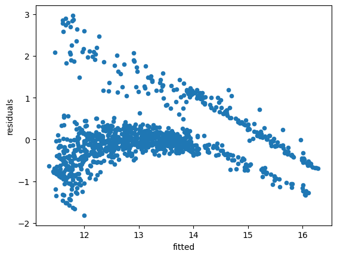

```python
test=pd.DataFrame()
test['residuals']=y_train-charge_predictions
test['fitted']=charge_predictions
test.plot.scatter(y='residuals',x='fitted')
plt.show()
```

The residuals suggest some violations to the assumptions of linear regression. As fitted values get larger, the residuals trend downward. I expect an even band, centered around zero. This does not necessarily make the model predictions unusable, but it puts into question the linear regression assumptions.

# Interpreting The Model

```python
coefficients
```

```
array([0.05026514, 0.01732919, 2.25222063])
```

# Final Model Evaluation

The training error is almost always overly optimistic, so it shouldn't be used as the final judge of the model's predictive ability. It's time to see how the model performs on the test data, which represents a set of new observations that it hasn't been trained on. Predictions should be accurate on any new observations if we want to use it in the new world.

```python
test_charges_preds = model.predict(X_test)
```

```python
test_mse=mean_squared_error(test_charges_preds,y_test)
test_mse
```

```
0.391234125893836
```

```python
np.exp(test_mse)
```

```
1.478804699358065
```

# Drawing Conclusions

The test MSE was about 0.391, while the training MSE was about 0.464. In this case, the test data is predicted more accurately than the training data, so we can conclude that the model is not overfit. The residuals suggest that the model is predicting much lower costs for subjects who were actually charged much higher. Therefore the model struggles with these higher costs. As a whole, the model predictions are too conservative.

The model can likely be improved by including more complex terms in the regression, such as interactions or quadratic terms.